# Guided tour of movement data with Motus package

Biodiversity Informatics (BIOL 475/575)

March 16, 2022

Programmer: AAA

**Important** - The answers to the 10 questions below can be figured out by working through the online guide to Motus in R, which is at motuswts.github.io and linked through D2L. (Although a couple questions ask you to interpret code or change code using common sense or by googling how to do things or by asking a friend.)

### Header

```r
# Load Libraries
library(ezknitr)
library(ggplot2)

# Clear Environment & Set Seed
remove(list=ls())
set.seed(71587)
```

## 1. Load libraries from new sources (ch 2)

```r
#Install "remotes" package
# install.packages("remotes")
# library(remotes)
# update_packages()

# install.packages(c("motus", "motusData"),
 #                 repos = c(birdscanada = 'https://birdscanada.r-universe.dev',
  #                          CRAN = 'https://cloud.r-project.org'))

#
 install.packages(c("rnaturalearthhires", "rnaturalearthdata"),
                repos = c(ropensci = 'https://ropensci.r-universe.dev',
                            CRAN = 'https://cloud.r-project.org'))
```

Load the packages for use

```r
library(motus)
library(motusData)
library(tidyverse)
library(DBI)
library(RSQLite)
library(lubridate)
library(rnaturalearth)
```

Set the system environment time to “UTC”

```r
Sys.setenv(TZ = "UTC")
```

**Q1** What time zone is UTC?

> Answer: universal coordinated time. on the prime meridian

**Q2** Why is this important?

> Answer: used for a universal time for all countries for work that may be globally

## 2. Download sample dataset (Ch 3)

**Important** - First, make a folder named “motus” in the same place as your folder named “biodiversity_informatics”

Set project number

```r
proj.num <- 176
```

Download the data

```r
# Log in name and password are: motus.sample
```

**Important** After first download, comment out the code above and use this:

```r
sql.motus <- tagme(projRecv = proj.num,
                   new = FALSE,
                   update = TRUE,
                   dir = "../motus")
```

```
## Checking for new data in project 176
```

```
## Updating metadata
```

```
## activity:     1 new batch records to check
```

```
## batchID  1977125 (#     1 of      1): got    156 activity records
```

```
## batchID  1977125 (#     1 of      1): got      0 activity records
```

```
## Downloaded 156 activity records
```

```
## nodeData:     0 new batch records to check
```

```
## Fetching deprecated batches
```

```
## Total deprecated batches: 6
## New deprecated batches: 0
```

```r
# Log in name and password are: motus.sample
```

## 3. Explore data that were downloaded (ch 3)

Specify the filename of where your data were downloaded

```r
file.name <- dbConnect(SQLite(), "../motus/project-176.motus")
```

Get a list of tables that were downloaded

```r
dbListTables(file.name)
```

```
##  [1] "activity"    "activityAll" "admInfo"     "allambigs"   "allruns"
##  [6] "allrunsGPS"  "alltags"     "alltagsGPS"  "antDeps"     "batchRuns"
## [11] "batches"     "clarified"   "deprecated"  "filters"     "gps"
## [16] "gpsAll"      "hits"        "meta"        "nodeData"    "nodeDeps"
## [21] "projAmbig"   "projBatch"   "projs"       "recvDeps"    "recvs"
## [26] "runs"        "runsFilters" "species"     "tagAmbig"    "tagDeps"
## [31] "tagProps"    "tags"
```

```r
# [1] "activity"    "activityAll" "admInfo"     "allambigs"   "allruns"
# [6] "allrunsGPS"  "alltags"     "alltagsGPS"  "antDeps"     "batchRuns"
# [11] "batches"     "clarified"   "deprecated"  "filters"     "gps"
# [16] "gpsAll"      "hits"        "meta"        "nodeData"    "nodeDeps"
# [21] "projAmbig"   "projBatch"   "projs"       "recvDeps"    "recvs"
# [26] "runs"        "runsFilters" "species"     "tagAmbig"    "tagDeps"
# [31] "tagProps"    "tags"
```

**Q3** What type of information is in the “projs” table?

> Answer: Project metadata

Get a list of fields (column names) in the table “species”

```r
dbListFields(file.name, "species")
```

```
## [1] "id"         "english"    "french"     "scientific" "group"      "sort"
```

**Q4** How many fields are in the “species” table?

> Answer: 6

Retrieve the virtual “alltags” table from the SQLite file

```r
tbl.alltags <- tbl(sql.motus, "alltags")
```

This is in a different format (list) than we are used to (data.frames). We can use str() to see what this different format contains:

```r
str(tbl.alltags)
```

```
## List of 2
##  $ src:List of 2
##   ..$ con  :Formal class 'SQLiteConnection' [package "RSQLite"] with 8 slots
##   .. .. ..@ ptr                :<externalptr>
##   .. .. ..@ dbname             : chr "/home/christopherkrueth/motus/project-176.motus"
##   .. .. ..@ loadable.extensions: logi TRUE
##   .. .. ..@ flags              : int 70
##   .. .. ..@ vfs                : chr ""
##   .. .. ..@ ref                :<environment: 0x5afa4a2a67f8>
##   .. .. ..@ bigint             : chr "integer64"
##   .. .. ..@ extended_types     : logi FALSE
##   ..$ disco:<environment: 0x5afa49f18438>
##   ..- attr(*, "class")= chr [1:4] "src_SQLiteConnection" "src_dbi" "src_sql" "src"
##  $ ops:List of 2
##   ..$ x   : 'ident' chr "alltags"
##   ..$ vars: chr [1:62] "hitID" "runID" "batchID" "ts" ...
##   ..- attr(*, "class")= chr [1:3] "op_base_remote" "op_base" "op"
##  - attr(*, "class")= chr [1:5] "tbl_SQLiteConnection" "tbl_dbi" "tbl_sql" "tbl_lazy" ...
```

The first part of the list, src, is a list that provides details of the SQLiteConnection, including the directory where the database is stored. The second part is a list that includes the underlying table. Thus, the R object alltags is a virtual table that stores the database structure and information required to connect to the underlying data in the .motus file.

We can use fairly straightforward commands to explore the table without changing its format. Later, we will convert a subset of this to a data.frame. For now, let's keep looking at it in the SQL format, which allows for faster processing.

```r
tbl.alltags %>%
  collect() %>%
  names()
```

```
##  [1] "hitID"          "runID"          "batchID"        "ts"
##  [5] "tsCorrected"    "sig"            "sigsd"          "noise"
##  [9] "freq"           "freqsd"         "slop"           "burstSlop"
## [13] "done"           "motusTagID"     "ambigID"        "port"
## [17] "nodeNum"        "runLen"         "motusFilter"    "bootnum"
## [21] "tagProjID"      "mfgID"          "tagType"        "codeSet"
## [25] "mfg"            "tagModel"       "tagLifespan"    "nomFreq"
## [29] "tagBI"          "pulseLen"       "tagDeployID"    "speciesID"
## [33] "markerNumber"   "markerType"     "tagDeployStart" "tagDeployEnd"
## [37] "tagDepLat"      "tagDepLon"      "tagDepAlt"      "tagDepComments"
## [41] "tagDeployTest"  "fullID"         "deviceID"       "recvDeployID"
## [45] "recvDeployLat"  "recvDeployLon"  "recvDeployAlt"  "recv"
## [49] "recvDeployName" "recvSiteName"   "isRecvMobile"   "recvProjID"
## [53] "recvUtcOffset"  "antType"        "antBearing"     "antHeight"
## [57] "speciesEN"      "speciesFR"      "speciesSci"     "speciesGroup"
## [61] "tagProjName"    "recvProjName"
```

**Q5** Compare this list to the one made when we just look at the field names directly (below). Which way was faster to process (if you can tell)?

> Answer: dbListFields(file.name, “alltags”)

```r
dbListFields(file.name, "alltags")
```

```
##  [1] "hitID"          "runID"          "batchID"        "ts"
##  [5] "tsCorrected"    "sig"            "sigsd"          "noise"
##  [9] "freq"           "freqsd"         "slop"           "burstSlop"
## [13] "done"           "motusTagID"     "ambigID"        "port"
## [17] "nodeNum"        "runLen"         "motusFilter"    "bootnum"
## [21] "tagProjID"      "mfgID"          "tagType"        "codeSet"
## [25] "mfg"            "tagModel"       "tagLifespan"    "nomFreq"
## [29] "tagBI"          "pulseLen"       "tagDeployID"    "speciesID"
## [33] "markerNumber"   "markerType"     "tagDeployStart" "tagDeployEnd"
## [37] "tagDepLat"      "tagDepLon"      "tagDepAlt"      "tagDepComments"
## [41] "tagDeployTest"  "fullID"         "deviceID"       "recvDeployID"
## [45] "recvDeployLat"  "recvDeployLon"  "recvDeployAlt"  "recv"
## [49] "recvDeployName" "recvSiteName"   "isRecvMobile"   "recvProjID"
## [53] "recvUtcOffset"  "antType"        "antBearing"     "antHeight"
## [57] "speciesEN"      "speciesFR"      "speciesSci"     "speciesGroup"
## [61] "tagProjName"    "recvProjName"
```

Now, let's convert that to a “flat” data.frame so that we can start exploring where these birds were detected!

```r
df.alltags <- tbl.alltags %>%
  collect() %>%
  as.data.frame() %>%     # for all fields in the df (data frame)
  mutate(time = as_datetime(ts))
```

Again, another way to see the column names:

```r
names(df.alltags)
```

```
##  [1] "hitID"          "runID"          "batchID"        "ts"
##  [5] "tsCorrected"    "sig"            "sigsd"          "noise"
##  [9] "freq"           "freqsd"         "slop"           "burstSlop"
## [13] "done"           "motusTagID"     "ambigID"        "port"
## [17] "nodeNum"        "runLen"         "motusFilter"    "bootnum"
## [21] "tagProjID"      "mfgID"          "tagType"        "codeSet"
## [25] "mfg"            "tagModel"       "tagLifespan"    "nomFreq"
## [29] "tagBI"          "pulseLen"       "tagDeployID"    "speciesID"
## [33] "markerNumber"   "markerType"     "tagDeployStart" "tagDeployEnd"
## [37] "tagDepLat"      "tagDepLon"      "tagDepAlt"      "tagDepComments"
## [41] "tagDeployTest"  "fullID"         "deviceID"       "recvDeployID"
## [45] "recvDeployLat"  "recvDeployLon"  "recvDeployAlt"  "recv"
## [49] "recvDeployName" "recvSiteName"   "isRecvMobile"   "recvProjID"
## [53] "recvUtcOffset"  "antType"        "antBearing"     "antHeight"
## [57] "speciesEN"      "speciesFR"      "speciesSci"     "speciesGroup"
## [61] "tagProjName"    "recvProjName"   "time"
```

**Q6** How many observations are there in this table?

> Answer: 188354

Let's select only a couple specific tag IDs. (The tag IDs are the IDs that each individual bird has)

```r
df.alltagsSub <- tbl.alltags %>%
  filter(motusTagID %in% c(16011, 23316)) %>%
  collect() %>%
  as.data.frame() %>%
  mutate(time = as_datetime(ts))
table(df.alltagsSub$motusTagID)
```

```
##
## 16011 23316
##   127  5734
```

**Q7** How many records are associated with each of the two tags?

> Answer: tag:16011 has 127 records. tag 23316 has 5734

## 4. Explore detections (Ch 5)

First, we'll just use the filtering function provided by Motus for this sample data. The details don't matter, we are just taking out any signals that are ambiguous or not biologically sensical.

```r
tbl.alltags <- tbl(sql.motus, "alltagsGPS")

# obtain a table object of the filter


# filter and convert the table into a dataframe, with a few modications
df.alltags.sub <- tbl.alltags %>%
  filter(motusFilter == 1) %>%
  select(-noise, -slop, -burstSlop, -done, -bootnum, -codeSet,
         -mfg, -nomFreq, -markerNumber, -markerType, -tagDepComments,
         -fullID, -deviceID, -recvDeployAlt,
         -speciesGroup, -gpsLat, -gpsLon, -recvSiteName) %>%
  collect() %>%
  mutate(time = as_datetime(ts),  # work with times AFTER transforming to flat file
         tagDeployStart = as_datetime(tagDeployStart),
         tagDeployEnd = as_datetime(tagDeployEnd),
         recvDeployName = if_else(is.na(recvDeployName),
                                  paste(recvDeployLat, recvDeployLon, sep=":"),
                                  recvDeployName))
```

Ok, now we can make some graphs and maps!

Let's see what time of day the different species of birds are usually detected during.

First, clean data up a little bit and round everything to the nearest hour of the day

```r
df.alltags.sub.2 <- df.alltags.sub %>%
  mutate(hour = lubridate::hour(time),
         year = lubridate::year(time),
         doy = lubridate::yday(time)) %>%
  select(motusTagID, port, tagDeployStart, tagDepLat, tagDepLon,
         recvDeployLat, recvDeployLon, recvDeployName, antBearing, speciesEN, year, doy, hour) %>%
  distinct()
```

Then graph it!

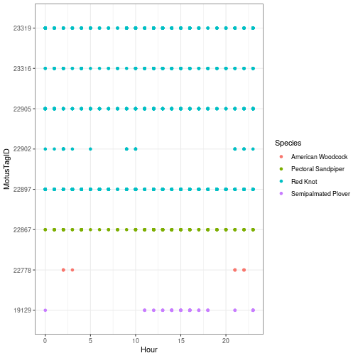

```r
ggplot(data = filter(df.alltags.sub.2, year(tagDeployStart) == 2016),
       aes(x = hour, y = as.factor(motusTagID), colour = speciesEN)) +
  theme_bw() +
  geom_point() +
  labs(x = "Hour", y = "MotusTagID") +
  scale_colour_discrete(name = "Species")
```

**Q8** Which two species of bird seem to be active only in the mornings and nights and not during the mid-day?

Simplify the data by summarizing by the runID so that we can map the detections

```r
# function to summarize data
fun.getpath <- function(df) {
  df %>%
    filter(tagProjID == 176, # keep only tags registered to the sample project
           !is.na(recvDeployLat) | !(recvDeployLat == 0)) %>%
    group_by(motusTagID, runID, recvDeployName, ambigID,
             tagDepLon, tagDepLat, recvDeployLat, recvDeployLon) %>%
    summarize(max.runLen = max(runLen), time = mean(time), .groups = "drop") %>%
    arrange(motusTagID, time) %>%
    data.frame()
} # end of function call

# applying function
df.alltags.path <- fun.getpath(df.alltags.sub)
```

Subset the cleaned data

```r
df.alltags.sub.path <- df.alltags.sub %>%
  filter(tagProjID == 176) %>% # only tags registered to project
  arrange(motusTagID, time) %>%       # order by time stamp for each tag
  mutate(date = as_date(time)) %>%    # create date variable
  group_by(motusTagID, date, recvDeployName, ambigID,
           tagDepLon, tagDepLat, recvDeployLat, recvDeployLon)

# Final data ready for plotting
df.alltags.path <- fun.getpath(df.alltags.sub.path)
```

Load some shapefiles to map

```r
world <- ne_countries(scale = "medium", returnclass = "sf")
# Run these two lines for the first time, then the subsequent lines every time after
# lakes <- ne_download(scale = "medium", type = 'lakes', category = 'physical',
#                               returnclass = "sf", destdir = "map-data")
lakes <- ne_load(type = "lakes", scale = "medium", category = 'physical',
                 returnclass = "sf",
                 destdir = "map-data") # use this if already downloaded shapefiles
```

We will just use the tags that have been examined carefully and filtered

```r
df.tmp <- df.alltags.path %>%
  filter(motusTagID %in% c(16011, 16035, 16036, 16037, 16038, 16039)) %>%
  arrange(time)  %>% # arrange by hour
  as.data.frame()
```

Set limits to map based on locations of detections, ensuring they include the deployment locations

```r
xmin <- min(df.tmp$recvDeployLon, na.rm = TRUE) - 2
xmax <- max(df.tmp$recvDeployLon, na.rm = TRUE) + 2
ymin <- min(df.tmp$recvDeployLat, na.rm = TRUE) - 1
ymax <- max(df.tmp$recvDeployLat, na.rm = TRUE) + 1
```

**Q9** What would you change above to zoom out on this map?

> Answer: x and y max would be increased

And now we can map the detections!

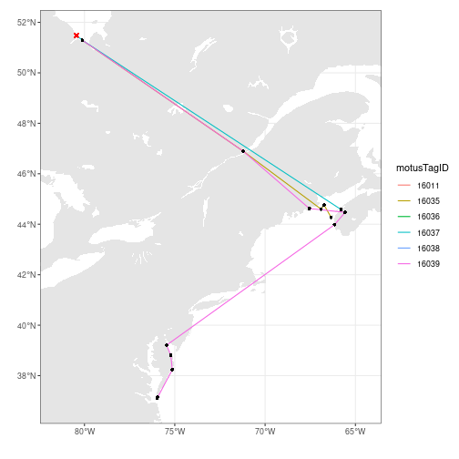

```r
ggplot(data = world) +
  geom_sf(colour = NA) +
  geom_sf(data = lakes, colour = NA, fill = "white") +
  coord_sf(xlim = c(xmin, xmax), ylim = c(ymin, ymax), expand = FALSE) +
  theme_bw() +
  labs(x = "", y = "") +
  geom_path(data = df.tmp,
            aes(x = recvDeployLon, y = recvDeployLat,
                group = as.factor(motusTagID), colour = as.factor(motusTagID))) +
  geom_point(data = df.tmp, aes(x = recvDeployLon, y = recvDeployLat),
             shape = 16, colour = "black") +
  geom_point(data = df.tmp,
             aes(x = tagDepLon, y = tagDepLat), colour = "red", shape = 4) +
  scale_colour_discrete("motusTagID")
```

**Q10** Duplicate the map below (two maps in final html), but change these items:

- Make the lake filled with “blue” instead of white

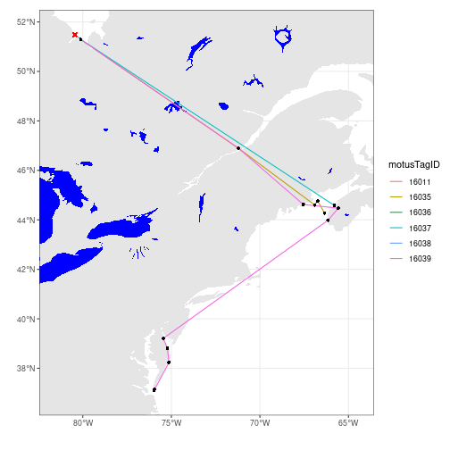

```r
ggplot(data = world) +
  geom_sf(colour = NA) +
  geom_sf(data = lakes, colour = NA, fill = "blue") +
  coord_sf(xlim = c(xmin, xmax), ylim = c(ymin, ymax), expand = FALSE) +
  theme_bw() +
  labs(x = "", y = "") +
  geom_path(data = df.tmp,
            aes(x = recvDeployLon, y = recvDeployLat,
                group = as.factor(motusTagID), colour = as.factor(motusTagID))) +
  geom_point(data = df.tmp, aes(x = recvDeployLon, y = recvDeployLat),
             shape = 16, colour = "black") +
  geom_point(data = df.tmp,
             aes(x = tagDepLon, y = tagDepLat), colour = "red", shape = 4) +
  scale_colour_discrete("motusTagID")
```

- Label x with “Longitude” and y with “Latitude”

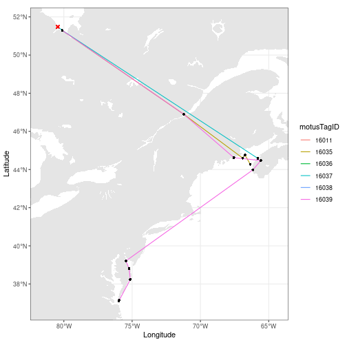

```r
ggplot(data = world) +
  geom_sf(colour = NA) +
  geom_sf(data = lakes, colour = NA, fill = "white") +
  coord_sf(xlim = c(xmin, xmax), ylim = c(ymin, ymax), expand = FALSE) +
  theme_bw() +
  labs(x = "Longitude", y = "Latitude") +
  geom_path(data = df.tmp,
            aes(x = recvDeployLon, y = recvDeployLat,
                group = as.factor(motusTagID), colour = as.factor(motusTagID))) +
  geom_point(data = df.tmp, aes(x = recvDeployLon, y = recvDeployLat),
             shape = 16, colour = "black") +
  geom_point(data = df.tmp,
             aes(x = tagDepLon, y = tagDepLat), colour = "red", shape = 4) +
  scale_colour_discrete("motusTagID")
```

### Footer

spin this with:

```r
 ezspin(file = "Chris/programs/20220316_Motus_lab.R",out_dir = "Chris/output", fig_dir = "figures",keep_md = FALSE, keep_rmd = FALSE)
```

[output not shown]